# seaborn_Plotting functions

- 官网手册目录（http://seaborn.pydata.org/tutorial.html）
  > - Style management
  > - Plotting functions
  > - Structured grids
- Plotting functions
  > - Visualizing the distribution of a dataset
  >   > - Plotting univariate distributions
  >   > - Plotting bivariate distributions
  >   > - Visualizing pairwise relationships in a dataset
  > - Visualizing linear relationships
  >   > - Functions to draw linear regression models
  >   > - Fitting different kinds of models
  >   > - Conditioning on other variables
  >   > - Controlling the size and shape of the plot
  >   > - Plotting a regression in other contexts
  > - Plotting with categorical data
  >   > - Categorical scatterplots
  >   > - Distributions of observations within categories
  >   > - Statistical estimation within categories
  >   > - Plotting “wide-form” data
  >   > - Drawing multi-panel categorical plots

## 一、可视化数据分布（Visualizing the distribution of a dataset）

```python
%matplotlib inline

import numpy as np
import pandas as pd
from scipy import stats, integrate
import matplotlib.pyplot as plt
import seaborn as sns

sns.set(color_codes=True)
np.random.seed(sum(map(ord, "distributions")))
```

### 1 绘制单变量分布（Plotting univariate distributions）

- 最简便查看单变量分布的方法是distplot()。默认会画一个直方图和核密度估计（KDE）
  > - The most convenient way to take a quick look at a univariate distribution in seaborn is the distplot() function.
  > - By default, this will draw a histogram and fit a kernel density estimate (KDE).

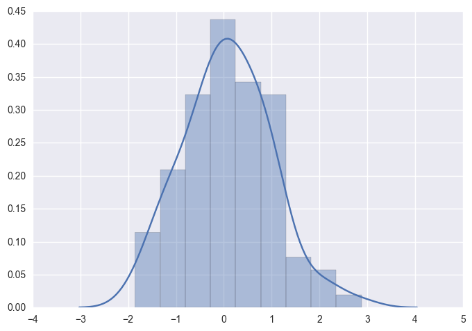

```python
x = np.random.normal(size=100)
sns.distplot(x);
```

#### 1.1 直方图（Histograms）

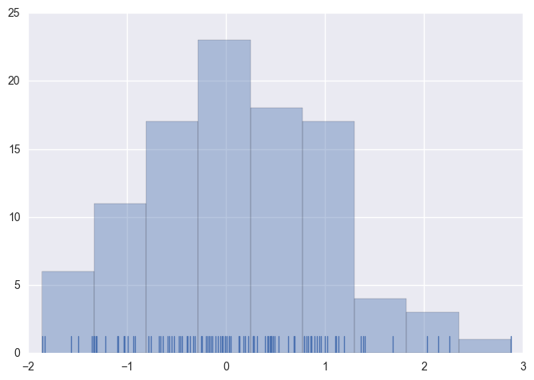

```python
sns.distplot(x, kde=False, rug=True);
# remove the density curve and add a rug plot, which draws a small vertical tick at each observation
```

- 主要参数是bins 的数量和位置。distplot()会自动选择合适的数量，不过尝试不同的数量可能发现数据的不同特征
  > - When drawing histograms, the main choice you have is the number of bins to use and where to place them.
  > - distplot() uses a simple rule to make a good guess for what the right number is by default, but trying more or fewer bins might reveal other features in the data

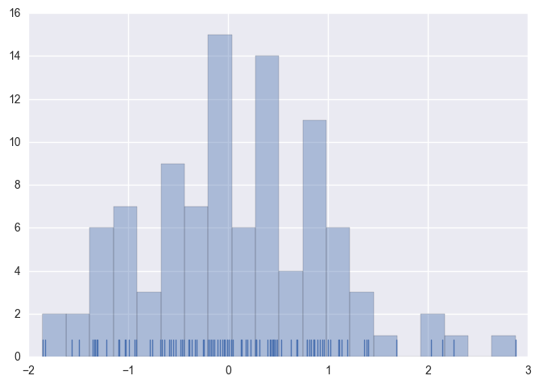

```python
sns.distplot(x, bins=20, kde=False, rug=True);
```

#### 1.2 核密度估计（Kernel density estimaton）

- a useful tool for plotting the shape of a distribution

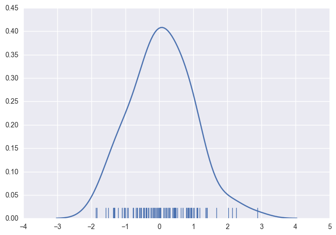

```python
sns.distplot(x, hist=False, rug=True);
```

- KDE比直方图的计算量更大。首先会以某点为中心画正态分布曲线
  > - Drawing a KDE is more computationally involved than drawing a histogram.
  > - What happens is that each observation is first replaced with a normal (Gaussian) curve centered at that value:

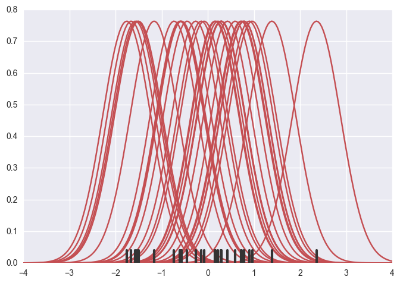

```python
x = np.random.normal(0, 1, size=30)
bandwidth = 1.06 * x.std() * x.size ** (-1 / 5.)
support = np.linspace(-4, 4, 200)

kernels = []
for x_i in x:

    kernel = stats.norm(x_i, bandwidth).pdf(support)
    kernels.append(kernel)
    plt.plot(support, kernel, color="r")

sns.rugplot(x, color=".2", linewidth=3);
```

- 然后，相加这些曲线以计算每个点的密度值
  > - Next, these curves are summed to compute the value of the density at each point in the support grid.
  > - The resulting curve is then normalized so that the area under it is equal to 1:

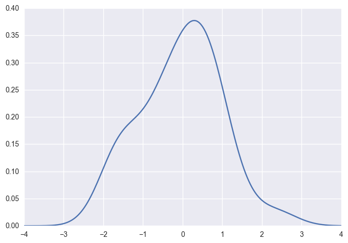

```python
density = np.sum(kernels, axis=0)
density /= integrate.trapz(density, support)
plt.plot(support, density);
```

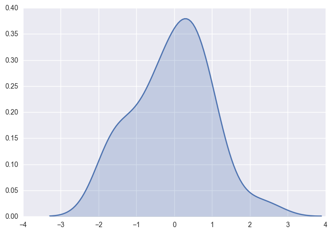

```python
sns.kdeplot(x, shade=True); # sns 中画图
```

- 参数bw控制拟合数据时的密集程度，它相当于上面图中核的宽度。默认会自动估计合适的，但也可以尝试不同的值：
  > - The bandwidth (bw) parameter of the KDE controls how tightly the estimation is fit to the data, much like the bin size in a histogram.
  > - It corresponds to the width of the kernels we plotted above.
  > - The default behavior tries to guess a good value using a common reference rule, but it may be helpful to try larger or smaller values:

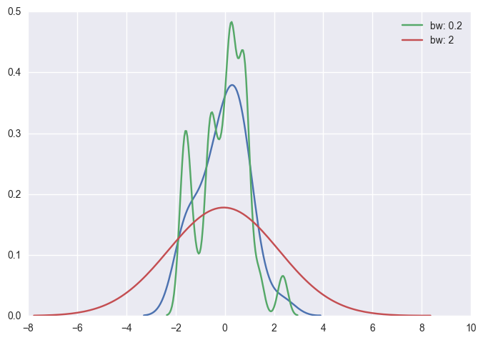

```python
sns.kdeplot(x)
sns.kdeplot(x, bw=.2, label="bw: 0.2")
sns.kdeplot(x, bw=2, label="bw: 2")
plt.legend();
```

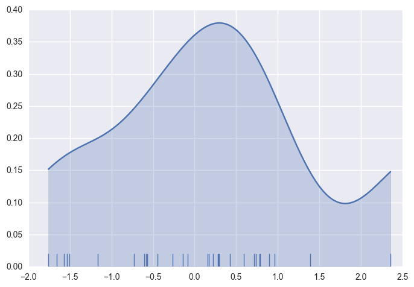

```python
# It’s possible to control how far past the extreme values the curve is drawn with the cut parameter;
# however, this only influences how the curve is drawn and not how it is fit:
sns.kdeplot(x, shade=True, cut=0)
sns.rugplot(x);
```

#### 1.3 拟合参数估计（Fitting parametric distributions）

- 使用（特定）参数分布拟合数据
  > - fit a parametric distribution to a dataset and visually evaluate how closely it corresponds to the observed data:

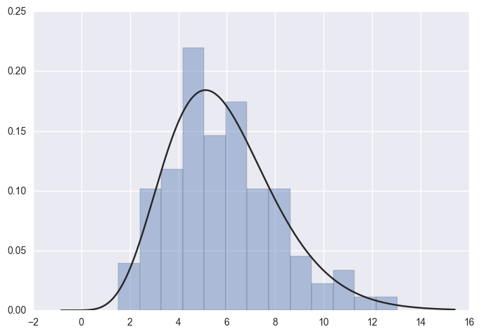

```python
x = np.random.gamma(6, size=200)
sns.distplot(x, kde=False, fit=stats.gamma);
```

### 2 绘制双变量分布（Plotting bivariate distributions）

- jointplot()函数。绘制多面板图形，能够显示双变量（或联合变量）的关系
  > - the jointplot() function, which creates a multi-panel figure that shows both the bivariate (or joint) relationship between two variables along with the univariate (or marginal) distribution of each on separate axes.

```python
mean, cov = [0, 1], [(1, .5), (.5, 1)]
data = np.random.multivariate_normal(mean, cov, 200)
df = pd.DataFrame(data, columns=["x", "y"])
```

#### 1.1 散点图（Scatterplots）

- You can draw a scatterplot with the matplotlib plt.scatter function, and it is also the default kind of plot shown by the jointplot() function:

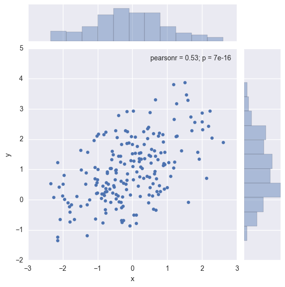

```python
sns.jointplot(x="x", y="y", data=df);
```

#### 1.2 六边形图（Hexbin plots）

- 对相对比较大的数据有用
  > - The bivariate analogue of a histogram is known as a “hexbin” plot, because it shows the counts of observations that fall within hexagonal bins.
  > - This plot works best with relatively large datasets.
  > - It’s availible through the matplotlib plt.hexbin function and as a style in jointplot().

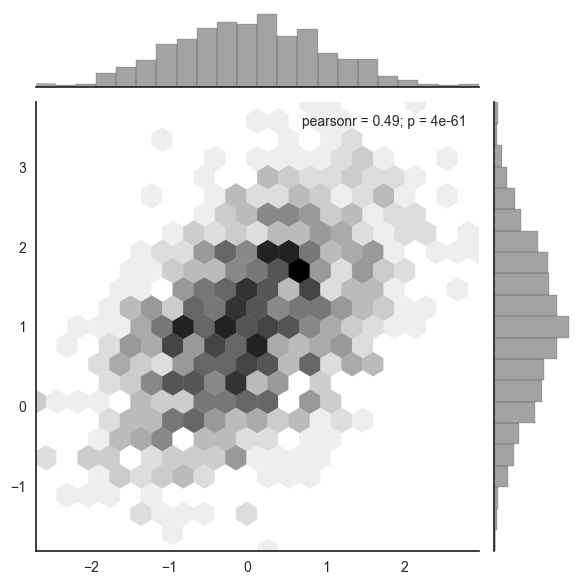

```python
x, y = np.random.multivariate_normal(mean, cov, 1000).T
with sns.axes_style("white"):
    sns.jointplot(x=x, y=y, kind="hex", color="k");
```

#### 1.3 核密度估计（Kernel density estimation）

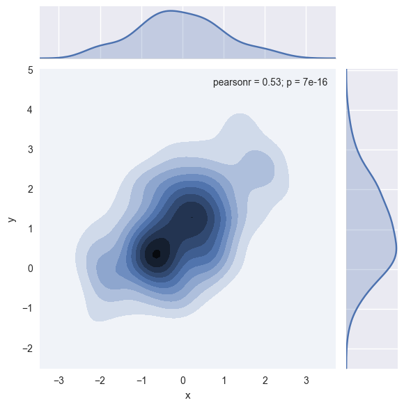

```python
sns.jointplot(x="x", y="y", data=df, kind="kde");
```

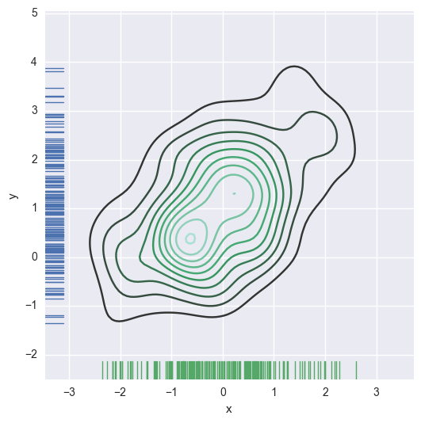

```python
f, ax = plt.subplots(figsize=(6, 6))
sns.kdeplot(df.x, df.y, ax=ax)
sns.rugplot(df.x, color="g", ax=ax)
sns.rugplot(df.y, vertical=True, ax=ax);
```

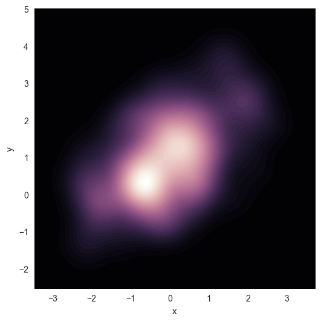

```python
# 连续：If you wish to show the bivariate density more continuously, you can simply increase the number of contour levels:
f, ax = plt.subplots(figsize=(6, 6))
cmap = sns.cubehelix_palette(as_cmap=True, dark=0, light=1, reverse=True)
sns.kdeplot(df.x, df.y, cmap=cmap, n_levels=60, shade=True);
```

- 如果要更灵活得控制图形，可使用JointGrid直接绘图。这样就可以绘制多层或者进行旋转
  > - The jointplot() function uses a JointGrid to manage the figure.
  > - For more flexibility, you may want to draw your figure by using JointGrid directly.
  > - jointplot() returns the JointGrid object after plotting, which you can use to add more layers or to tweak other aspects of the visualization:

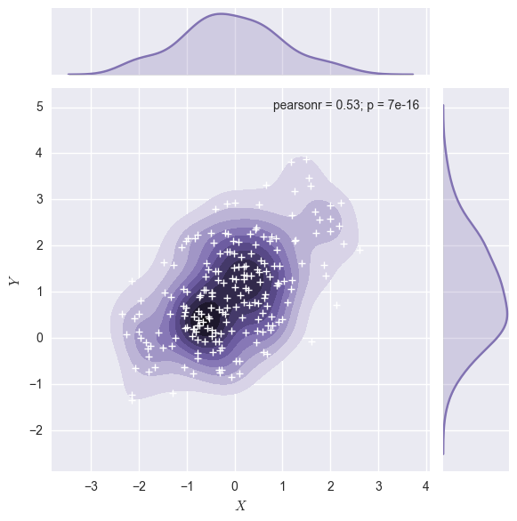

```python
g = sns.jointplot(x="x", y="y", data=df, kind="kde", color="m")
g.plot_joint(plt.scatter, c="w", s=30, linewidth=1, marker="+")
g.ax_joint.collections[0].set_alpha(0)
g.set_axis_labels("$X$", "$Y$");
```

### 3 可视化数据的相互关系（Visualizing pairwise relationships in a dataset）

- This creates a matrix of axes and shows the relationship for each pair of columns in a DataFrame.
- by default, it also draws the univariate distribution of each variable on the diagonal Axes:

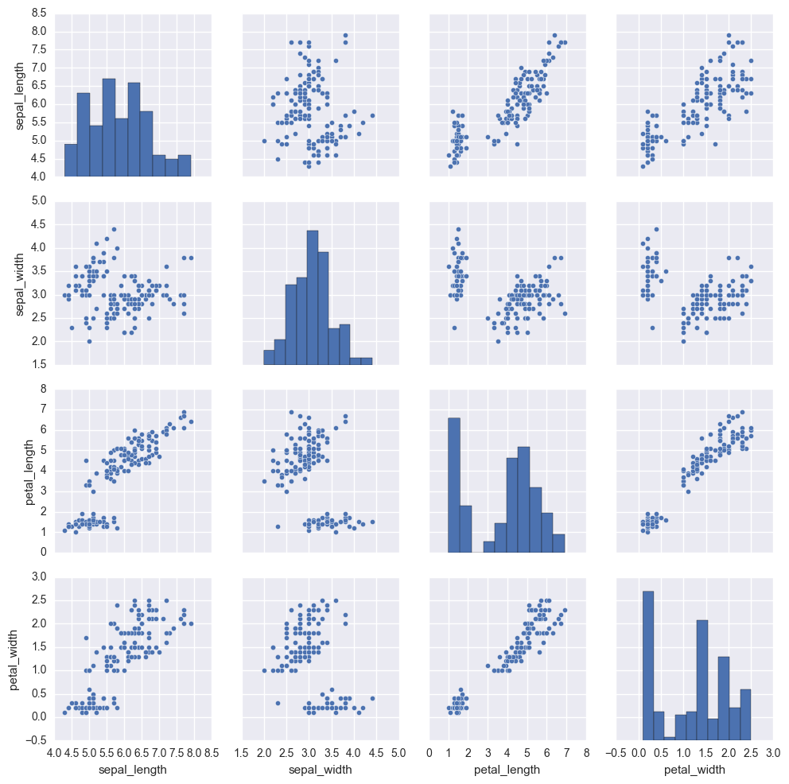

```python
iris = sns.load_dataset("iris")
sns.pairplot(iris);
```

- Much like the relationship between jointplot() and JointGrid, the pairplot() function is built on top of a PairGrid object, which can be used directly for more flexibility:

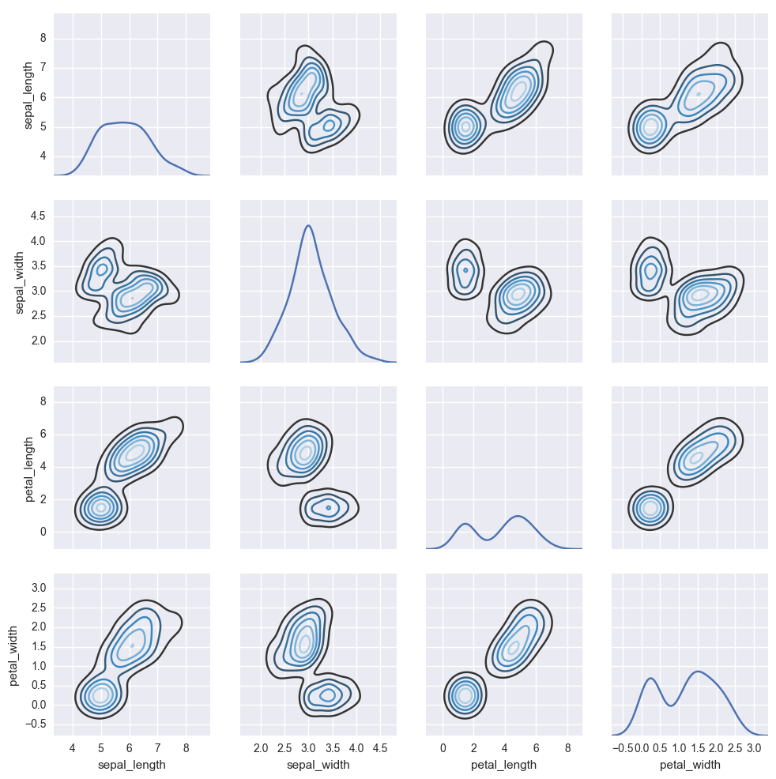

```python
g = sns.PairGrid(iris)
g.map_diag(sns.kdeplot)
g.map_offdiag(sns.kdeplot, cmap="Blues_d", n_levels=6);
```